# Carotid intima-media thickness in adults with and without rheumatoid arthritis

Dataset 10: Cardiovascular risk and carotid artery thickness in rheumatoid arthritis

RSR feasibility analysis

2026-08-03

# Introduction

The source study recruited adults with rheumatoid arthritis (RA) and healthy controls without RA in the Netherlands, put every participant through the same physical examination and fasting laboratory panel, and measured carotid intima-media thickness (cIMT) semi-automatically by B-mode ultrasound (Hollan and colleagues, *PLOS ONE*, 2015). This teaching extract holds 470 participants, 307 with RA and 163 controls. Carotid intima-media thickness is a non-invasive structural marker of early atherosclerosis that predicts subsequent myocardial infarction and stroke, and the long-standing clinical claim is that the chronic systemic inflammation of RA accelerates it beyond what conventional risk factors explain.

**Aim.** Among these Dutch adults, we examined which of RA status, age, sex, adiposity, blood pressure, smoking, lipid-lowering and antihypertensive treatment, the fasting lipid panel, glucose and C-reactive protein are independently associated with carotid intima-media thickness, mutually adjusting for the others.

This is a *Purpose 3* analysis: several predictors are of interest and the question is which remain associated with the outcome after mutual adjustment.

# Methods

**Data source.** A cross-sectional case-control comparison conducted in the Netherlands and published in *PLOS ONE* in 2015. Cases were adults with established rheumatoid arthritis; controls were adults without RA recruited from the same setting. This extract contains 470 participants and 25 variables: anthropometry, blood pressure, current medication, a fasting lipid and glucose panel, C-reactive protein, and the two carotid ultrasound measures. Ages run from 20 to 70 years.

**Variables.** The outcome is `cimt_total`, mean carotid intima-media thickness across both sides, in millimetres, treated as continuous (median 0.56 mm, range 0.15 to 1.06 mm). Predictors are rheumatoid arthritis status (reference Control), age in years, sex (reference Female), BMI in kg/m2, systolic blood pressure in mmHg, current smoking (reference No), statin use (reference No), antihypertensive use (reference No), total cholesterol, HDL cholesterol and triglycerides in mmol/L, fasting glucose in mmol/L, and log-transformed C-reactive protein. **RA status is the exposure of primary interest**; the remainder are conventional cardiovascular risk factors carried as covariates.

Cases and controls were **not matched on age or sex** (RA cases have median age 55 versus 53 years for controls, and 32% versus 40% men), so age and sex are forced into every adjusted model regardless of their own significance.

**Variables deliberately excluded, and why.** Six candidate predictors are left out on structural grounds, fixed before any model was fitted.

- `weight_kg` and `height_cm`: `bmi` is exactly `weight_kg / (height_cm/100)^2` in this file (largest discrepancy across all rows 3.6e-15 kg/m2, i.e. floating-point noise), so including any two of the three is a deterministic relationship.
- `waist_cm`: correlated 0.81 with BMI. Both measure adiposity; BMI is kept because it is the more completely recorded of the two.
- `diastolic_bp`: correlated 0.67 with systolic blood pressure. Systolic pressure is kept because it is the stronger correlate of arterial structure at these ages.
- `ldl_cholesterol`: **LDL in this file is not independently measured, it is calculated.** Against the Friedewald formula (`total - HDL - triglycerides/2.2`) it correlates 0.9987 with a mean absolute discrepancy of 0.041 mmol/L, which is rounding. Putting total cholesterol, HDL, triglycerides *and* LDL in one model is therefore a near-exact linear dependency; doing so inflates the variance inflation factors for the lipid terms into the hundreds (documented in the feasibility notes).
- `apo_a` and `apo_b`: apolipoprotein B correlates 0.83 with total cholesterol and apolipoprotein A correlates 0.55 with HDL; they are alternative measurements of the same two lipid fractions rather than additional information.
- `hypertension_or_hyperchol`: every participant taking an antihypertensive or a statin is coded 1 on this variable, so it is a structural superset of two predictors already in the model.

**Parameter budget.** With 449 complete cases and 13 predictors, all of which cost one degree of freedom, the model estimates 13 parameters, i.e. 35 observations per parameter. That is comfortably inside the 10-15 observations per parameter that a linear model needs, so the cap here is imposed by collinearity rather than by sample size.

**Statistical analysis.** `lm()`, justified because the outcome is a continuous measurement in millimetres with a roughly symmetric distribution. We fitted a univariable model for each predictor first, then a single multivariable model containing all of them. Predictors were chosen in advance on subject-matter grounds, not by significance. Significance threshold 0.05; estimates are reported with 95% confidence intervals. Assumptions were checked with `performance::check_model()`, supplemented by `check_collinearity()`, and because non-constant variance was flagged we additionally report HC3 heteroscedasticity-consistent standard errors. C-reactive protein is used as a predictor on the **log scale**: raw CRP has skewness 5.1 and a range of 1 to 71, so untransformed it would let a handful of participants with CRP above 40 dominate its coefficient. Analysis used R version 4.6.0 (2026-04-24) with tidyverse, gtsummary and performance.

**Data integrity.** The catalogue notes that in the original Zenodo deposit `sex` was coded 0 = woman / 1 = man and the height column mixed metres and centimetres. Both look corrected in the shipped CSV: `sex` takes the values female and male, and `height_cm` runs from 145 to 206 cm with 0 values below 3 (i.e. none left in metres). One residual defect remains: row `id = "control_row1"` is **entirely empty** apart from `id`, `has_ra` and `hypertension_or_hyperchol`, so the file’s 470 rows are really 469 participants plus one blank record. It is dropped by complete-case analysis and does not affect any estimate here.

**Missing data.** Complete-case analysis: 449 of 470 rows were analysed (21 dropped, 4.5%). The outcome itself is 98.3% complete (8 missing); the remaining attrition is spread thinly across the predictors, the largest single contributors being `crp` (5 missing), `statins` (6) and `current_smoker` (4). Only 406 of 470 rows are complete on *every* column in the file, so adding predictors would cost further rows.

# Results

## Sample characteristics

**Table 1. Sample characteristics of the analytic sample, by rheumatoid arthritis status.**

| **Characteristic** | **N** | **Control** N = 156<sup>1</sup> | **RA** N = 293<sup>1</sup> |
| --- | --- | --- | --- |
| cIMT (mm) | 449 | 0.57 (0.49, 0.63) | 0.56 (0.49, 0.65) |
| Age (years) | 449 | 53 (44, 61) | 55 (46, 62) |
| Sex | 449 |  |  |
| Female |  | 94 (60%) | 198 (68%) |
| Male |  | 62 (40%) | 95 (32%) |
| BMI (kg/m2) | 449 | 25.2 (22.4, 27.3) | 26.0 (23.5, 29.0) |
| Systolic BP (mmHg) | 449 | 124 (116, 134) | 130 (120, 140) |
| Current smoker | 449 | 23 (15%) | 59 (20%) |
| Taking a statin | 449 | 21 (13%) | 13 (4.4%) |
| Taking antihypertensives | 449 | 29 (19%) | 54 (18%) |
| Total cholesterol (mmol/L) | 449 | 5.40 (4.70, 6.00) | 5.40 (4.60, 6.00) |
| HDL cholesterol (mmol/L) | 449 | 1.50 (1.20, 1.80) | 1.40 (1.20, 1.70) |
| Triglycerides (mmol/L) | 449 | 1.22 (0.82, 1.67) | 1.04 (0.75, 1.49) |
| Fasting glucose (mmol/L) | 449 | 5.20 (4.80, 5.70) | 5.40 (5.10, 5.80) |
| log CRP (log mg/L) | 449 | 0.00 (0.00, 1.10) | 1.10 (0.00, 1.79) |

<sup>1</sup> Median (Q1, Q3); n (%)

The two groups are broadly similar in crude cIMT (median 0.56 mm in RA versus 0.57 mm in controls) but not in the things that drive cIMT: RA cases are on average 1.7 years older, have systolic pressure about 6 mmHg higher, and are a more female group. Their C-reactive protein is markedly higher (median 3 versus 1 mg/L), which is the expected signature of active systemic inflammation.

## Exploratory figure

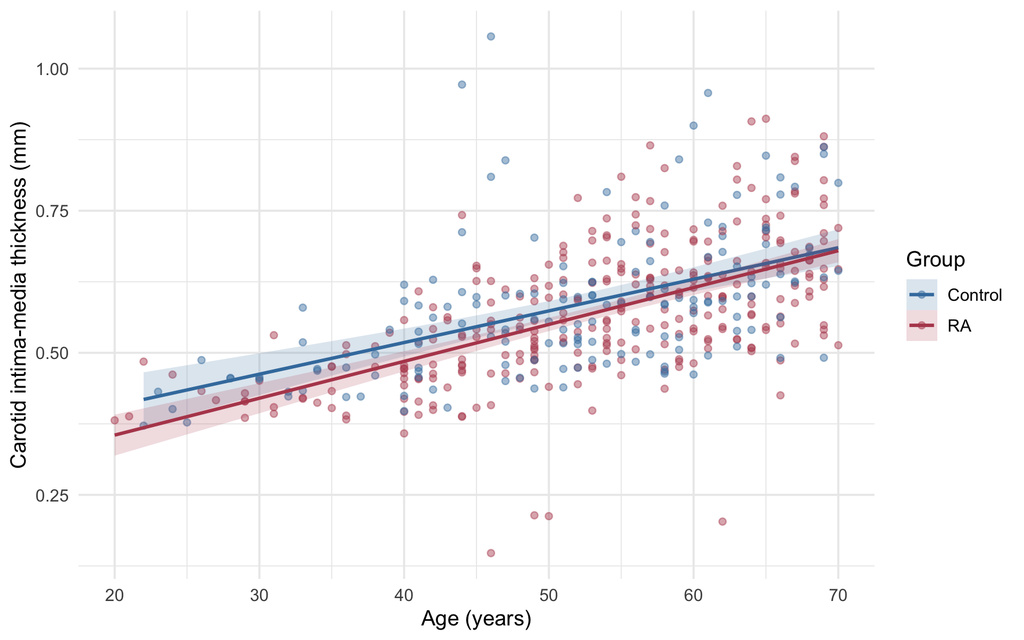

Figure 1. Carotid intima-media thickness against age, separately for participants with rheumatoid arthritis and controls, with linear smoothers and 95% confidence bands.

Carotid intima-media thickness rises steadily and near-linearly with age in both groups, and the two smoothers lie almost on top of one another, with the RA line slightly *below* the control line across most of the age range - so whatever RA contributes, it is not a visible upward shift in cIMT at a given age.

## Univariable models

| **Characteristic** | **N** | **Beta** | **95% CI** | **p-value** |
| --- | --- | --- | --- | --- |
| Age (years) | 449 | 0.01 | 0.01, 0.01 | <0.001 |
| Sex | 449 |  |  |  |
| Female |  | — | — |  |
| Male |  | 0.04 | 0.01, 0.06 | 0.004 |
| Rheumatoid arthritis | 449 |  |  |  |
| Control |  | — | — |  |
| RA |  | -0.01 | -0.04, 0.01 | 0.4 |
| BMI (kg/m2) | 449 | 0.00 | 0.00, 0.01 | <0.001 |
| Systolic BP (mmHg) | 449 | 0.00 | 0.00, 0.00 | <0.001 |
| Current smoker | 449 |  |  |  |
| No |  | — | — |  |
| Yes |  | 0.01 | -0.02, 0.04 | 0.4 |
| Taking a statin | 449 |  |  |  |
| No |  | — | — |  |
| Yes |  | 0.07 | 0.02, 0.11 | 0.003 |
| Taking antihypertensives | 449 |  |  |  |
| No |  | — | — |  |
| Yes |  | 0.06 | 0.03, 0.08 | <0.001 |
| Total cholesterol (mmol/L) | 449 | 0.02 | 0.01, 0.03 | <0.001 |
| HDL cholesterol (mmol/L) | 449 | -0.01 | -0.03, 0.02 | 0.5 |
| Triglycerides (mmol/L) | 449 | 0.02 | 0.00, 0.04 | 0.021 |
| Fasting glucose (mmol/L) | 449 | 0.02 | 0.01, 0.04 | 0.002 |
| log CRP (log mg/L) | 449 | 0.00 | -0.01, 0.02 | 0.5 |

Abbreviation: CI = Confidence Interval

Age is by far the strongest crude predictor: each additional year is associated with 0.0061 mm (95% CI 0.0052 to 0.0069) greater cIMT (p <0.001), i.e. about 0.06 mm per decade against a sample median of 0.56 mm. Systolic blood pressure follows (0.0025 mm (95% CI 0.0019 to 0.0032) per mmHg, p <0.001), then BMI (0.0046 mm (95% CI 0.0020 to 0.0071) per kg/m2, p <0.001), fasting glucose (0.0249 mm (95% CI 0.0092 to 0.0406) per mmol/L, p = 0.002), total cholesterol (0.0212 mm (95% CI 0.0110 to 0.0314) per mmol/L, p <0.001) and triglycerides (0.0191 mm (95% CI 0.0029 to 0.0353), p = 0.021). Men average 0.0351 mm (95% CI 0.0115 to 0.0588) more than women (p = 0.004). The two treatment indicators look like strong *risk* markers: statin users average 0.0658 mm (95% CI 0.0231 to 0.1084) more cIMT (p = 0.003) and participants on antihypertensives 0.0552 mm (95% CI 0.0263 to 0.0841) more (p <0.001). Crucially, **the exposure of interest shows nothing crudely**: RA status is associated with -0.0113 mm (95% CI -0.0352 to 0.0126) (p = 0.351), a difference that is both small and firmly non-significant. Current smoking (p = 0.387), HDL cholesterol (p = 0.510) and log CRP (p = 0.451) show no crude association.

## Why adjustment is needed

**Age** is the confounder that matters most, and it works directly against the exposure of interest. Age is the dominant determinant of cIMT in this sample (crude 0.0061 mm (95% CI 0.0052 to 0.0069) per year), and because cases and controls were not age-matched the RA group is 1.7 years older on average. The RA group therefore carries an age-driven *upward* push on cIMT that masks whatever the disease itself contributes; adding age alone moves the RA coefficient from -0.0113 mm (95% CI -0.0352 to 0.0126) to -0.0217 mm. **Systolic blood pressure** does the same job for the same reason: RA cases average 6.5 mmHg higher, and higher pressure independently thickens the arterial wall, so part of the RA group’s cIMT is a blood-pressure difference rather than a disease effect. **Sex** is a third: men have thicker intima-media at every age (0.0351 mm (95% CI 0.0115 to 0.0588) crude) and the RA group is more female (32% men versus 40%), which pushes the crude RA estimate in the opposite direction to age. Finally, **age confounds the two treatment indicators**: statin users are on average 5.6 years older than non-users, which is enough on its own to generate the crude “statins are associated with thicker arteries” result. Mutual adjustment lets each estimate be read as a comparison between participants of the same age, sex, body mass, blood pressure, lipid profile and treatment status.

## Multivariable model

| **Characteristic** | **Beta** | **95% CI** | **p-value** |
| --- | --- | --- | --- |
| Age (years) | 0.01 | 0.00, 0.01 | <0.001 |
| Sex |  |  |  |
| Female | — | — |  |
| Male | 0.02 | 0.00, 0.04 | 0.13 |
| Rheumatoid arthritis |  |  |  |
| Control | — | — |  |
| RA | -0.03 | -0.05, -0.01 | 0.009 |
| BMI (kg/m2) | 0.00 | 0.00, 0.00 | 0.11 |
| Systolic BP (mmHg) | 0.00 | 0.00, 0.00 | <0.001 |
| Current smoker |  |  |  |
| No | — | — |  |
| Yes | 0.02 | 0.00, 0.05 | 0.064 |
| Taking a statin |  |  |  |
| No | — | — |  |
| Yes | 0.02 | -0.02, 0.06 | 0.4 |
| Taking antihypertensives |  |  |  |
| No | — | — |  |
| Yes | 0.01 | -0.02, 0.04 | 0.5 |
| Total cholesterol (mmol/L) | 0.00 | -0.01, 0.01 | 0.6 |
| HDL cholesterol (mmol/L) | -0.01 | -0.03, 0.02 | 0.7 |
| Triglycerides (mmol/L) | 0.00 | -0.02, 0.01 | 0.8 |
| Fasting glucose (mmol/L) | 0.00 | -0.02, 0.01 | 0.9 |
| log CRP (log mg/L) | 0.00 | -0.01, 0.01 | 0.9 |

Abbreviation: CI = Confidence Interval

**Model fit: multivariable linear model for carotid intima-media thickness**

| Statistic | Value |
| --- | --- |
| Complete-case N | 449 |
| Parameters (excl. intercept) | 13 |
| Observations per parameter | 34.5 |
| R-squared | 0.362 |
| Adjusted R-squared | 0.343 |
| Residual SE (mm) | 0.0994 |

Three predictors survive adjustment. Among participants of the same sex, RA status, body mass, blood pressure, smoking status, treatment and laboratory profile, each additional year of age is associated with 0.0052 mm (95% CI 0.0042 to 0.0062) greater cIMT (p <0.001), i.e. 0.05 mm per decade. Among participants alike on everything else, each additional mmHg of systolic pressure is associated with 0.0011 mm (95% CI 0.0005 to 0.0017) (p <0.001), or 0.011 mm per 10 mmHg. And the exposure of interest becomes significant only *after* adjustment: among participants of the same age, sex and cardiovascular risk profile, those with RA have -0.0285 mm (95% CI -0.0498 to -0.0072) cIMT (p = 0.009) - a **thinner**, not thicker, intima-media. Nothing else reaches significance: BMI (0.0019 mm (95% CI -0.0004 to 0.0043), p = 0.112), current smoking (0.0230 mm (95% CI -0.0013 to 0.0473), p = 0.064), statins (0.0177 mm (95% CI -0.0210 to 0.0564), p = 0.370), antihypertensives (0.0092 mm (95% CI -0.0169 to 0.0353), p = 0.490), total cholesterol (0.0029 mm (95% CI -0.0077 to 0.0135), p = 0.589), HDL (-0.0050 mm (95% CI -0.0304 to 0.0204), p = 0.698), triglycerides (-0.0017 mm (95% CI -0.0180 to 0.0145), p = 0.833), glucose (-0.0009 mm (95% CI -0.0151 to 0.0132), p = 0.898) and log CRP (0.0007 mm (95% CI -0.0100 to 0.0115), p = 0.895) are all null. These are associations among the participants observed, not effects of intervening.

## Unadjusted versus adjusted

**Table 2. Unadjusted and adjusted estimates for carotid intima-media thickness.**

| **Characteristic** | **Unadjusted** **N** | **Unadjusted** **Beta** | **Unadjusted** **95% CI** | **Unadjusted** **p-value** | **Adjusted** **Beta** | **Adjusted** **95% CI** | **Adjusted** **p-value** |
| --- | --- | --- | --- | --- | --- | --- | --- |
| Age (years) | 449 | 0.01 | 0.01, 0.01 | <0.001 | 0.01 | 0.00, 0.01 | <0.001 |
| Sex | 449 |  |  |  |  |  |  |
| Female |  | — | — |  | — | — |  |
| Male |  | 0.04 | 0.01, 0.06 | 0.004 | 0.02 | 0.00, 0.04 | 0.13 |
| Rheumatoid arthritis | 449 |  |  |  |  |  |  |
| Control |  | — | — |  | — | — |  |
| RA |  | -0.01 | -0.04, 0.01 | 0.4 | -0.03 | -0.05, -0.01 | 0.009 |
| BMI (kg/m2) | 449 | 0.00 | 0.00, 0.01 | <0.001 | 0.00 | 0.00, 0.00 | 0.11 |
| Systolic BP (mmHg) | 449 | 0.00 | 0.00, 0.00 | <0.001 | 0.00 | 0.00, 0.00 | <0.001 |
| Current smoker | 449 |  |  |  |  |  |  |
| No |  | — | — |  | — | — |  |
| Yes |  | 0.01 | -0.02, 0.04 | 0.4 | 0.02 | 0.00, 0.05 | 0.064 |
| Taking a statin | 449 |  |  |  |  |  |  |
| No |  | — | — |  | — | — |  |
| Yes |  | 0.07 | 0.02, 0.11 | 0.003 | 0.02 | -0.02, 0.06 | 0.4 |
| Taking antihypertensives | 449 |  |  |  |  |  |  |
| No |  | — | — |  | — | — |  |
| Yes |  | 0.06 | 0.03, 0.08 | <0.001 | 0.01 | -0.02, 0.04 | 0.5 |
| Total cholesterol (mmol/L) | 449 | 0.02 | 0.01, 0.03 | <0.001 | 0.00 | -0.01, 0.01 | 0.6 |
| HDL cholesterol (mmol/L) | 449 | -0.01 | -0.03, 0.02 | 0.5 | -0.01 | -0.03, 0.02 | 0.7 |
| Triglycerides (mmol/L) | 449 | 0.02 | 0.00, 0.04 | 0.021 | 0.00 | -0.02, 0.01 | 0.8 |
| Fasting glucose (mmol/L) | 449 | 0.02 | 0.01, 0.04 | 0.002 | 0.00 | -0.02, 0.01 | 0.9 |
| log CRP (log mg/L) | 449 | 0.00 | -0.01, 0.02 | 0.5 | 0.00 | -0.01, 0.01 | 0.9 |

Abbreviation: CI = Confidence Interval

The two treatment indicators move furthest, and both move *toward* the null. Statin use falls from 0.0658 mm (95% CI 0.0231 to 0.1084) crude (p = 0.003) to 0.0177 mm (95% CI -0.0210 to 0.0564) adjusted (p = 0.370), losing about 73% of its magnitude and its significance; antihypertensive use falls from 0.0552 mm (95% CI 0.0263 to 0.0841) (p <0.001) to 0.0092 mm (95% CI -0.0169 to 0.0353) (p = 0.490). This is confounding by indication compounded by age: statin and antihypertensive users are older and have higher blood pressure, and once age and pressure are held constant the apparent “harm” of treatment disappears. Total cholesterol behaves the same way, from 0.0212 mm (95% CI 0.0110 to 0.0314) (p <0.001) to 0.0029 mm (95% CI -0.0077 to 0.0135) (p = 0.589), as does glucose, which crosses from 0.0249 mm (95% CI 0.0092 to 0.0406) (p = 0.002) to -0.0009 mm (95% CI -0.0151 to 0.0132) (p = 0.898) - both crude estimates were essentially age in disguise.

One estimate moves decisively *away* from the null, and it is the exposure of interest. RA status goes from -0.0113 mm (95% CI -0.0352 to 0.0126) (p = 0.351) to -0.0285 mm (95% CI -0.0498 to -0.0072) (p = 0.009), roughly 2.5 times larger in magnitude, and crosses *into* significance. This is negative confounding: the RA group’s greater age and higher blood pressure were concealing a modest negative association, and removing them uncovers it. By contrast **age barely moves** - 0.0061 mm (95% CI 0.0052 to 0.0069) crude to 0.0052 mm (95% CI 0.0042 to 0.0062) adjusted, a change of about 15% - which is what one expects of a variable that nothing else in the model can stand in for. Systolic blood pressure is intermediate: it more than halves, from 0.0025 mm (95% CI 0.0019 to 0.0032) to 0.0011 mm (95% CI 0.0005 to 0.0017), but stays clearly significant, so part of the crude blood-pressure gradient was age and part of it is its own.

## Diagnostics

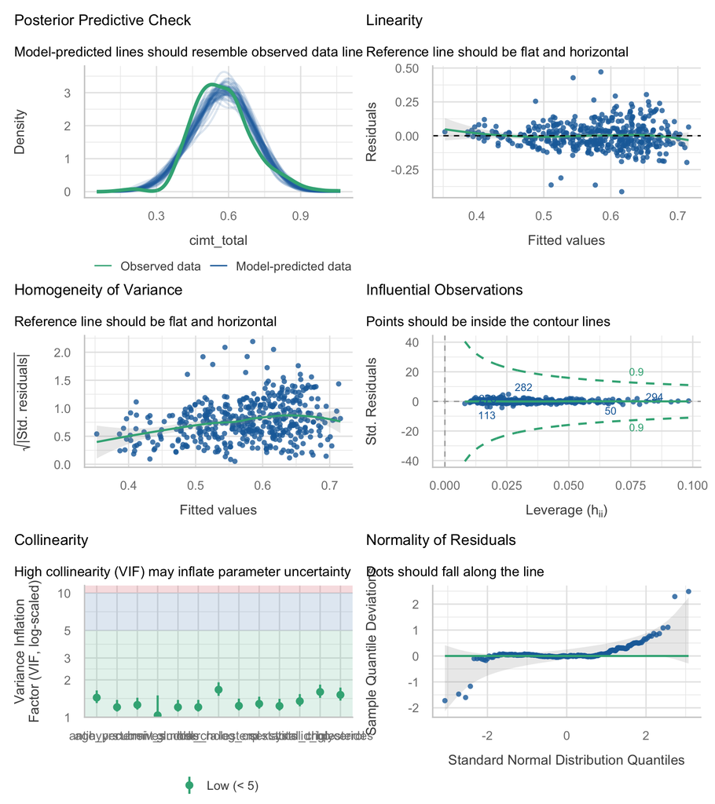

| Term | VIF | VIF_CI_low | VIF_CI_high | SE_factor | Tolerance | Tolerance_CI_low | Tolerance_CI_high |
| --- | --- | --- | --- | --- | --- | --- | --- |
| age_yrs | 1.439695 | 1.300426 | 1.643526 | 1.199873 | 0.6945916 | 0.6084481 | 0.7689789 |
| sex | 1.283658 | 1.173366 | 1.464115 | 1.132986 | 0.7790237 | 0.6830066 | 0.8522488 |
| has_ra | 1.206604 | 1.112312 | 1.380060 | 1.098455 | 0.8287720 | 0.7246062 | 0.8990281 |
| bmi | 1.258200 | 1.152994 | 1.435751 | 1.121695 | 0.7947864 | 0.6964998 | 0.8673074 |
| systolic_bp | 1.347345 | 1.224877 | 1.536508 | 1.160752 | 0.7422006 | 0.6508266 | 0.8164084 |
| current_smoker | 1.036618 | 1.002688 | 1.498810 | 1.018145 | 0.9646750 | 0.6671962 | 0.9973190 |
| statins | 1.233008 | 1.133010 | 1.408185 | 1.110409 | 0.8110250 | 0.7101338 | 0.8826050 |
| antihypertensives | 1.206066 | 1.111893 | 1.379497 | 1.098210 | 0.8291420 | 0.7249019 | 0.8993667 |
| total_cholesterol | 1.599293 | 1.432179 | 1.831025 | 1.264632 | 0.6252764 | 0.5461422 | 0.6982365 |
| hdl_cholesterol | 1.666879 | 1.488221 | 1.910915 | 1.291077 | 0.5999234 | 0.5233096 | 0.6719430 |

[output cut: 3 more lines]

**Table 3. Would a transformation of the outcome help?**

| Outcome | Residual skewness | Shapiro-Wilk p | R-squared |
| --- | --- | --- | --- |
| cIMT (mm, untransformed) | 0.39 | 6.8e-10 | 0.362 |
| log(cIMT) | -1.48 | 2.9e-17 | 0.357 |
| sqrt(cIMT) | -0.36 | 7.7e-12 | 0.368 |

**Table 4. HC3 heteroscedasticity-consistent standard errors.**

| Term | Estimate | SE (OLS) | SE (HC3) | 95% CI (HC3) | p (HC3) |
| --- | --- | --- | --- | --- | --- |
| age_yrs | 0.0052 | 0.0005 | 0.0005 | 0.0043 to 0.0061 | 0.000 |
| sexMale | 0.0170 | 0.0111 | 0.0115 | -0.0056 to 0.0396 | 0.139 |
| has_raRA | -0.0285 | 0.0108 | 0.0116 | -0.0513 to -0.0057 | 0.015 |
| bmi | 0.0019 | 0.0012 | 0.0012 | -0.0004 to 0.0042 | 0.101 |
| systolic_bp | 0.0011 | 0.0003 | 0.0003 | 0.0005 to 0.0018 | 0.001 |
| current_smokerYes | 0.0230 | 0.0124 | 0.0146 | -0.0056 to 0.0516 | 0.115 |
| statinsYes | 0.0177 | 0.0197 | 0.0214 | -0.0244 to 0.0597 | 0.409 |
| antihypertensivesYes | 0.0092 | 0.0133 | 0.0127 | -0.0159 to 0.0342 | 0.472 |
| total_cholesterol | 0.0029 | 0.0054 | 0.0048 | -0.0066 to 0.0124 | 0.548 |
| hdl_cholesterol | -0.0050 | 0.0129 | 0.0102 | -0.0250 to 0.0150 | 0.622 |
| triglycerides | -0.0017 | 0.0083 | 0.0080 | -0.0175 to 0.0141 | 0.828 |
| glucose | -0.0009 | 0.0072 | 0.0063 | -0.0133 to 0.0114 | 0.883 |
| log_crp | 0.0007 | 0.0055 | 0.0054 | -0.0098 to 0.0113 | 0.893 |

**Linearity and predicted values.** The residual-versus-fitted panel is close to flat, and Figure 1 already showed that the age-cIMT relationship is essentially straight, so the linear specification is defensible. The posterior-predictive check reproduces the bulk of the cIMT distribution well but slightly under-predicts the right shoulder.

**Collinearity is not a problem in this model.** The largest variance inflation factor is 1.67 (for hdl_cholesterol) and every VIF is below 2.0, well short of the conventional threshold of 5. That is a direct consequence of the exclusions set out in Methods: the same model with `waist_cm`, `diastolic_bp` and `ldl_cholesterol` added has VIFs of about 503 for the lipid terms.

**Variance is not constant.** `check_heteroscedasticity()` rejects constant error variance (p < 0.001): participants predicted to have thicker intima-media also vary more around their prediction, which is the usual pattern for a measurement with a floor near zero. Table 4 therefore reports HC3 robust standard errors. They change nothing substantive - the HC3 standard error for the RA coefficient is 0.0116 against an OLS 0.0108, and age, systolic pressure and RA status keep their significance status under robust inference.

**Residuals are non-normal, but a transformation is the wrong fix.** `check_normality()` rejects (p < 0.001). The cause is not skew - residual skewness is only 0.39 - but heavy tails: residual kurtosis is 6.0 against 3 for a normal distribution, driven by a small number of participants with unusually thin or unusually thick arteries. Table 3 shows that log-transforming the outcome makes matters clearly *worse* (residual skewness -1.48, i.e. a strong left tail, and a smaller Shapiro-Wilk p-value), and the square-root transform is no better; the outcome is therefore left on its natural millimetre scale, where the coefficients are directly interpretable. With 449 observations the central limit theorem covers the coefficient standard errors, and the HC3 intervals are the ones we rely on.

**No influential observations.** The largest Cook’s distance is 0.043 and the largest leverage 0.098, so no single participant drives the fit.

# Discussion

In this Dutch case-control sample, carotid intima-media thickness is dominated by age and systolic blood pressure: about 0.05 mm per decade of age and 0.011 mm per 10 mmHg of systolic pressure, each holding the other constant. Rheumatoid arthritis itself shows **no crude association** with cIMT, and after adjustment for age, sex and conventional risk factors the RA group has intima-media that is 0.028 mm *thinner* (p = 0.009). Against a median cIMT of 0.56 mm that is a difference of roughly 5%, and it is around 5.5 years’ worth of ageing - real but small. The practical reading is that in this sample the hypothesis that RA accelerates subclinical atherosclerosis is not supported; the cardiovascular risk carried by these RA patients is the risk carried by their age and their blood pressure.

The result that most deserves caution is the pair of treatment indicators. Both statin use and antihypertensive use look strongly *harmful* in the crude analysis, and neither survives adjustment. That is confounding by indication in its purest form: people are prescribed statins **because** their lipids and overall cardiovascular risk are poor, and prescribed antihypertensives **because** their blood pressure is high. In this sample statin users are on average 5.6 years older and, despite treatment, have total cholesterol of 4.7 mmol/L against 5.5 in non-users. Neither the crude nor the adjusted coefficient can be read as an effect of treatment: the adjusted one conditions on the very lipid and pressure values that treatment was given to change, which is adjusting for a mediator. These indicators belong in the model as risk *markers* and should be described that way, never as evidence about whether statins work.

**Limitations.** The design is cross-sectional, so no temporal ordering is established and the RA coefficient cannot be read as an effect of developing RA. Cases and controls were not matched on age or sex, so all comparisons rest on statistical adjustment; residual confounding by age is likely because age enters linearly while the age-cIMT relationship may curve at the extremes. The RA group’s disease-specific characteristics - disease duration, DAS28 activity score, methotrexate, prednisone and anti-TNF exposure - are **not in this extract at all** (they are undefined for the 163 controls), so we cannot distinguish RA patients with active from quiescent disease, and the null RA finding may conceal a real association confined to poorly controlled patients. Immunosuppressive treatment could itself reduce cIMT, in which case the negative RA coefficient is a treatment effect masquerading as a disease effect. Statin and antihypertensive use are confounded by indication as described above, and adjusting for the lipid and blood-pressure values they modify is over-adjustment. Error variance is non-constant and residuals are heavy-tailed; HC3 standard errors address inference but not the model’s fit in the tails. Complete-case analysis dropped 21 of 470 rows. The sample is a single Dutch centre and is not representative of any wider population. All estimates are associations, not causal effects.

**Future work.** Refit with the RA-specific disease-activity and treatment variables from the full deposit, restricted to the RA cases, to test whether cumulative inflammatory burden rather than the RA label predicts intima-media thickness.

# Feasibility notes

*NOT part of a student report.*

- **USABLE, and the best of the three outcomes in this dataset.** The outcome is 98.3% complete, the complete-case N is 449 of 470, R-squared is 0.362, and there is a clean, strong, genuinely interpretable signal in age and systolic pressure. It is also a good teaching case because the exposure of interest is null crudely and significant only after adjustment.
- **MAJOR trap: `ldl_cholesterol` is the Friedewald calculation, not an independent measurement.** Against `total_cholesterol - hdl_cholesterol - triglycerides/2.2` it correlates 0.9987 (mean absolute discrepancy 0.041 mmol/L). A student who puts all four lipid variables in one model gets VIFs of roughly 500 (`total_cholesterol`), 410 (`ldl_cholesterol`), 93 (`hdl_cholesterol`) and 36 (`triglycerides`), with standard errors an order of magnitude too large and coefficients that flip sign. This is the single most likely way a student wrecks this outcome. The `meta.json` predictor list currently suggests all four.
- **MAJOR interpretive trap: `statins` and `antihypertensives` are confounded by indication.** Both look harmful crudely (statins 0.0658 mm (95% CI 0.0231 to 0.1084), p = 0.003) and both vanish on adjustment. A student who reports “statin use is associated with thicker arteries” without the indication caveat has written something clinically backwards. Worse, adjusting for cholesterol and blood pressure conditions on the mediators of treatment, so neither column of Table 2 is interpretable as a treatment effect.
- **MINOR-to-MAJOR: `bmi` and `waist_cm` (r 0.81) and `systolic_bp` and `diastolic_bp` (r 0.67) are redundant pairs.** Including both members of each pair raises their VIFs to about 3.5 and 2.2 respectively - not fatal, but it splits the adiposity and pressure signal across two coefficients and neither reaches significance.
- **MINOR: `apo_a`/`apo_b` duplicate HDL and total cholesterol** (r 0.55 and 0.83).
- **MINOR: `hypertension_or_hyperchol` is a structural superset of `statins` and `antihypertensives`** - every treated participant is coded 1 - so the three together are close to nested.
- **MINOR: `weight_kg` and `height_cm` must be excluded**; `bmi` is exactly `weight_kg/(height_cm/100)^2` (max discrepancy 3.6e-15).
- **MINOR failed diagnostics.** Non-constant variance (p < 0.001) and non-normal residuals (p < 0.001), the latter from kurtosis 6.0 rather than skew (skewness only 0.39). **Transformation does not help**: log(cIMT) gives residual skewness -1.48 and a worse Shapiro-Wilk p. HC3 standard errors are the right response and change no conclusion. This is a useful counter-example to the reflex “skewed-looking outcome, take logs”.
- **MINOR data defect: row `id = "control_row1"` is entirely blank** apart from `id`, `has_ra` and `hypertension_or_hyperchol`, so the advertised 470 rows are 469 participants plus one empty record. Harmless for complete-case work but it makes every “% complete” figure in the codebook one row pessimistic.
- **Verified clean:** `sex` ships as the strings female/male (the Zenodo 0/1 coding is fixed) and `height_cm` ranges 145-206 cm with 0 values in metres (the mixed-unit problem is fixed). No RA-specific columns (DAS28, methotrexate, anti-TNF) are present, as intended.
- **No parameter-budget pressure**: 449 observations for 13 parameters, 35 per parameter. The constraint on this model is collinearity, not N.